# Traditional food security

# Introduction

**in progress….**

Food security relates to the fundamental human right of access to food ([United Nations, 1948](https://www.un.org/en/about-us/universal-declaration-of-human-rights)). Specifically, food security is achieved when a reliable supply of food is available for a region/people ([Mbow et al., 2019](https://policycommons.net/artifacts/458644/food-security/1431487/)). In historically ostracised and remote communities, food security is a fundamental issue ([Salomon et al., 2020](http://coastalvoices.net/books-articles-reports)). The impact of colonial practices on indigenous people around the world has resulted in many communities losing their food sovereignty and security ([Whyte, 201](https://academic.oup.com/edited-volume/27989/chapter-abstract/211700194?redirectedFrom=fulltext)8). In a time of reconciliation, efforts to revitalise traditional practices and return rights to indigenous people must address food security problems ([Chuenpagdee and Jentoft, 2019](https://link.springer.com/book/10.1007/978-3-319-94938-3)).

## Facts

**Global**

“50,000 wild species are used by billions of people around the world.” ([Fromentin et al 2023](https://www.sciencedirect.com/science/article/abs/pii/S0959378023000584?via%3Dihub))

Many indigenous communities around the world face issues of food security, especially in remote areas. However, not all communities suffer from the same rates of food insecurity, even within similar ecological regions, for example about 25% of households in Western Alaska are food insecure compared to 69% in Nunavut (Chuenpagdee and Jentoft, 2019). In fact, Nunavut has the highest rate of food insecurity for any indigenous population living in a developed country ([Council of Canadian Academies, 2014](https://cca-reports.ca/reports/aboriginal-food-security-in-northern-canada-an-assessment-of-the-state-of-knowledge/)). Culture, history, local practices, environmental change, logistics and governance systems all play a role in food security outcomes. **Figure 1** presents a conceptual framework for understanding the multiple contributors to food security in modern indigenous communities.

**Figure 1**. presents a conceptual framework for understanding the multiple contributors to food security in modern indigenous communities.

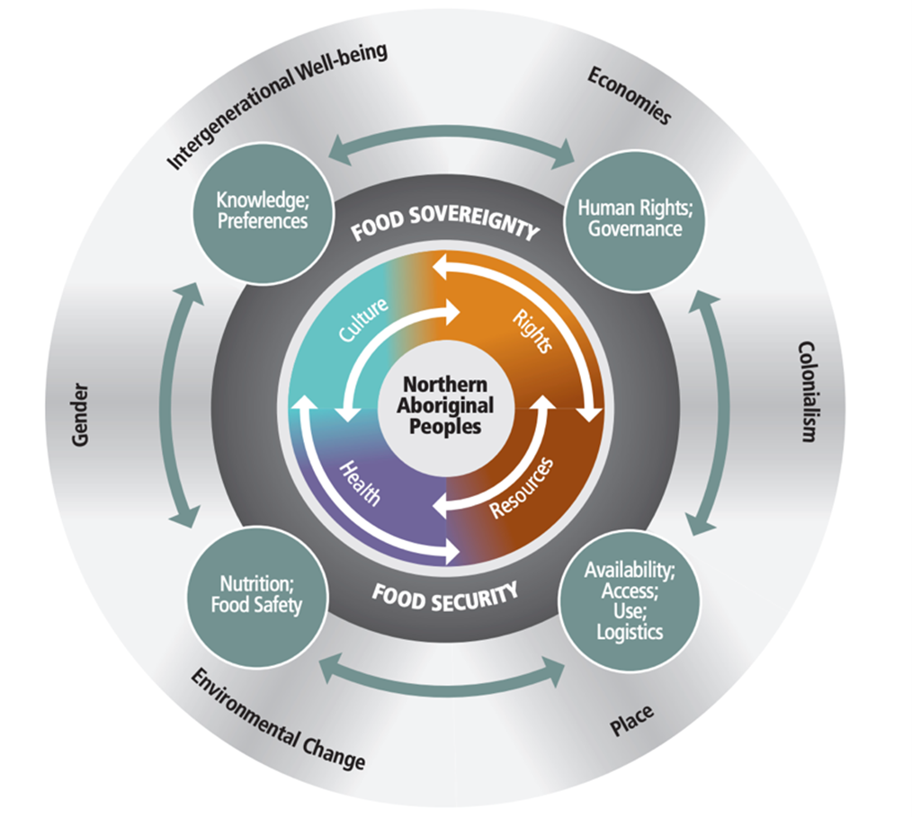

Figure 1. A conceptual representation of the multiple factors affecting food security in the Canadian North. “This dynamic, holistic, people-centred framework is a tool for analyzing and understanding food security and food sovereignty in northern Canada. The wheel represents the complex interplay between factors that affect northern Aboriginal peoples, and how food security and food sovereignty emerge from these relationships. Because the framework is fluid, no single factor should be interpreted as static or merely linked to the factor to which it is most closely positioned. Each factor is understood to have multiple relationships with other concepts within the wheel.” From [Council of Canadian Academies, 2014](https://cca-reports.ca/reports/aboriginal-food-security-in-northern-canada-an-assessment-of-the-state-of-knowledge/).

## Case studies

[Domingo et al 2021](https://www.mdpi.com/1660-4601/18/9/4404)

[Swiderska et al 2022](https://www.mdpi.com/2071-1050/14/18/11311) Indigenous Peoples’ Food Systems and Biocultural Heritage

[Shafiee et al 2022](https://www.ncbi.nlm.nih.gov/pmc/articles/PMC9776675/) Food security status of indigenous people, Canada